# DO-MS Report

Version: 1.0.9 | Generated: 2019-06-08 10:04:13

## Summary

### MaxQuant Search Summary

MaxQuant Search Summary

MaxQuant Version: 1.6.2.3, 8

Search Date: 02/23/2019 10:39:47, 6

FASTA File: G:/My Drive/MS/DBs_Params/FASTA/swissprot_human_20180730.fasta, 28, 27

### Experiment Map

Map of raw file names to short names

| Short name | Raw file | Folder | Path |
| --- | --- | --- | --- |
| Exp FP94_1 4 | 190222S_LCA9_X_FP94_col21 | FP94_1 | C:/MQ_Searches/FP94_1 |
| Exp FP94_1 5 | 190222S_LCA9_X_FP94_col22 | FP94_1 | C:/MQ_Searches/FP94_1 |
| Exp FP94_2 12 | 190222S_LCA9_X_FP94AA | FP94_2 | C:/MQ_Searches/FP94_2 |
| Exp FP94_2 13 | 190222S_LCA9_X_FP94AB | FP94_2 | C:/MQ_Searches/FP94_2 |
| Exp FP94_2 14 | 190222S_LCA9_X_FP94AC | FP94_2 | C:/MQ_Searches/FP94_2 |
| Exp FP94_2 15 | 190222S_LCA9_X_FP94AD | FP94_2 | C:/MQ_Searches/FP94_2 |
| Exp FP94_2 16 | 190222S_LCA9_X_FP94AE | FP94_2 | C:/MQ_Searches/FP94_2 |
| Exp FP94_2 17 | 190222S_LCA9_X_FP94AF | FP94_2 | C:/MQ_Searches/FP94_2 |
| Exp FP94_2 18 | 190222S_LCA9_X_FP94AG | FP94_2 | C:/MQ_Searches/FP94_2 |
| Exp FP94_2 19 | 190222S_LCA9_X_FP94AH | FP94_2 | C:/MQ_Searches/FP94_2 |

[output cut: 57 more lines]

### MaxQuant Parameters

MaxQuant Search Parameters

|  | Parameter | 1 | 4 | 2 | 3 | 5 |
| --- | --- | --- | --- | --- | --- | --- |
| 1 | Folder Name | 1 | 4 | 2 | 3 | 5 |
| 2 | Folder Path | 1 | 4 | 2 | 3 | 5 |
| 3 | Version | 1.6.2.3 | 1.6.2.3 | 1.6.2.3 | 1.6.2.3 | 1.6.2.3 |
| 4 | User name | HMS-desk21 | HMS-desk21 | HMS-desk21 | HMS-desk21 | HMS-desk21 |
| 5 | Machine name | DESKTOP-2EM392J | DESKTOP-2EM392J | DESKTOP-2EM392J | DESKTOP-2EM392J | DESKTOP-2EM392J |
| 6 | Date of writing | 02/23/2019 10:39:47 | 02/28/2019 16:36:50 | 02/25/2019 13:21:50 | 02/28/2019 12:50:15 | 03/25/2019 11:44:05 |
| 7 | Include contaminants | True | True | True | True | True |
| 8 | PSM FDR | 1 | 1 | 1 | 1 | 1 |
| 9 | XPSM FDR-Intra protein | 0.01 | 0.01 | 0.01 | 0.01 | 0.01 |
| 10 | XPSM FDR-Inter protein | 0.05 | 0.05 | 0.05 | 0.05 | 0.05 |

[output cut: 96 more lines]

### MaxQuant Experiment Summary

MaxQuant experiment summary statistics

|  | Raw.file | Raw.file.orig | Enzyme | Enzyme.mode | Enzyme.first.search | Enzyme.mode.first.search | Use.enzyme.first.search | Variable.modifications | Fixed.modifications | Multi.modifications | Variable.modifications.first.search | Use.variable.modifications.first.search | Requantify | Multiplicity | Max..missed.cleavages | Labels0 | LC.MS.run.type | Time.dependent.recalibration | MS | MS.MS | MS3 | MS.MS.Submitted | MS.MS.Submitted..SIL. | MS.MS.Submitted..ISO. | MS.MS.Submitted..PEAK. | MS.MS.Identified | MS.MS.Identified..SIL. | MS.MS.Identified..ISO. | MS.MS.Identified..PEAK. | … |
| --- | --- | --- | --- | --- | --- | --- | --- | --- | --- | --- | --- | --- | --- | --- | --- | --- | --- | --- | --- | --- | --- | --- | --- | --- | --- | --- | --- | --- | --- | --- |
| 1 | Exp FP94_1 4 | 190222S_LCA9_X_FP94_col21 | Trypsin/P | Specific |  |  | False | Oxidation (M);Acetyl (Protein N-term);Deamidation (N);Acetyl (K) |  |  |  | False | False | 1 | 2 |  | Reporter ion MS2 |  | 8375 | 10593 | 0 | 11813 | 9373 | 0 | 2440 | 7154 | 6672 | 0 | 482 | … |
| 2 | Exp FP94_1 5 | 190222S_LCA9_X_FP94_col22 | Trypsin/P | Specific |  |  | False | Oxidation (M);Acetyl (Protein N-term);Deamidation (N);Acetyl (K) |  |  |  | False | False | 1 | 2 |  | Reporter ion MS2 |  | 8070 | 11061 | 0 | 12294 | 9828 | 0 | 2466 | 7512 | 6983 | 0 | 529 | … |
| 3 | Exp FP94_2 12 | 190222S_LCA9_X_FP94AA | Trypsin/P | Specific |  |  | False | Oxidation (M);Acetyl (Protein N-term);Deamidation (N);Acetyl (K) |  |  |  | False | False | 1 | 2 |  | Reporter ion MS2 |  | 12523 | 5127 | 0 | 5903 | 4351 | 0 | 1552 | 2940 | 2663 | 0 | 277 | … |
| 4 | Exp FP94_2 13 | 190222S_LCA9_X_FP94AB | Trypsin/P | Specific |  |  | False | Oxidation (M);Acetyl (Protein N-term);Deamidation (N);Acetyl (K) |  |  |  | False | False | 1 | 2 |  | Reporter ion MS2 |  | 9787 | 7349 | 0 | 8363 | 6335 | 0 | 2028 | 4474 | 4086 | 0 | 388 | … |
| 5 | Exp FP94_2 14 | 190222S_LCA9_X_FP94AC | Trypsin/P | Specific |  |  | False | Oxidation (M);Acetyl (Protein N-term);Deamidation (N);Acetyl (K) |  |  |  | False | False | 1 | 2 |  | Reporter ion MS2 |  | 9063 | 8476 | 0 | 9620 | 7332 | 0 | 2288 | 5167 | 4714 | 0 | 453 | … |
| 6 | Exp FP94_2 15 | 190222S_LCA9_X_FP94AD | Trypsin/P | Specific |  |  | False | Oxidation (M);Acetyl (Protein N-term);Deamidation (N);Acetyl (K) |  |  |  | False | False | 1 | 2 |  | Reporter ion MS2 |  | 9029 | 8578 | 0 | 9725 | 7431 | 0 | 2294 | 5199 | 4747 | 0 | 452 | … |
| 7 | Exp FP94_2 16 | 190222S_LCA9_X_FP94AE | Trypsin/P | Specific |  |  | False | Oxidation (M);Acetyl (Protein N-term);Deamidation (N);Acetyl (K) |  |  |  | False | False | 1 | 2 |  | Reporter ion MS2 |  | 10703 | 6219 | 0 | 7081 | 5357 | 0 | 1724 | 3737 | 3411 | 0 | 326 | … |
| 8 | Exp FP94_2 17 | 190222S_LCA9_X_FP94AF | Trypsin/P | Specific |  |  | False | Oxidation (M);Acetyl (Protein N-term);Deamidation (N);Acetyl (K) |  |  |  | False | False | 1 | 2 |  | Reporter ion MS2 |  | 11228 | 5553 | 0 | 6467 | 4639 | 0 | 1828 | 3198 | 2843 | 0 | 355 | … |
| 9 | Exp FP94_2 18 | 190222S_LCA9_X_FP94AG | Trypsin/P | Specific |  |  | False | Oxidation (M);Acetyl (Protein N-term);Deamidation (N);Acetyl (K) |  |  |  | False | False | 1 | 2 |  | Reporter ion MS2 |  | 9834 | 7425 | 0 | 8367 | 6483 | 0 | 1884 | 4484 | 4111 | 0 | 373 | … |
| 10 | Exp FP94_2 19 | 190222S_LCA9_X_FP94AH | Trypsin/P | Specific |  |  | False | Oxidation (M);Acetyl (Protein N-term);Deamidation (N);Acetyl (K) |  |  |  | False | False | 1 | 2 |  | Reporter ion MS2 |  | 9776 | 7544 | 0 | 8499 | 6589 | 0 | 1910 | 4531 | 4154 | 0 | 377 | … |

[output cut: 57 more lines]

## Chromatography

### Elution profile: FWHM

Plotting the distrution of elution profile widths at half the maximum intensity value for each peak.

[figure not shown]

### Identification frequency across gradient

Plotting the frequency of peptide identification across the chromatographic gradient.

[figure not shown]

### Retention length of peptides at base

Plotting the retention length of identified peptide peaks at the base.

[figure not shown]

## Ion Sampling

### Apex Offset

Plotting the distance from the peak of the elution profile the MS2 events were executed.

[figure not shown]

### MS1 Intensity for identified ions

Plotting the MS1 intensity for all identified ions across runs.

[figure not shown]

### MS1 Intensity for z>1 ions

Plotting the MS1 intensity for all peptide-like ions observed (not necessarily sent to MS2) across runs.

[figure not shown]

### MS1 Intensity for identified ions in common

Plotting the MS1 intensity for all common identified ions across runs.

[output not shown]

### MS1 Intensity for all ions

Plotting the MS1 intensity for all ions observed (not necessarily sent to MS2) across runs.

[figure not shown]

### Injection times, PSM resulting

Plotting distribution of injection times for MS2 events that did result in a PSM.

[figure not shown]

### Injection times, no PSM resulting

Plotting distribution of injection times for MS2 events that did not result in a PSM.

[figure not shown]

## Peptide Identifications

### Miscleavage rate

Plotting frequency of peptide miscleavages.

[figure not shown]

### Miscleavage rate percentage

Percentages of missed cleavages - measure the efficiency of protein digest

| Raw.file | None | 1 | 2 | % Missed cleavages |
| --- | --- | --- | --- | --- |
| Exp FP94_1 4 | 8936 | 2548 | 344 | 26.58561 |
| Exp FP94_1 5 | 9304 | 2880 | 356 | 27.85360 |
| Exp FP94_2 12 | 1568 | 361 | 54 | 23.02405 |
| Exp FP94_2 13 | 2599 | 697 | 98 | 25.57274 |
| Exp FP94_2 14 | 3009 | 812 | 125 | 26.08696 |
| Exp FP94_2 15 | 3029 | 788 | 124 | 25.48585 |
| Exp FP94_2 16 | 2186 | 575 | 77 | 25.00858 |
| Exp FP94_2 17 | 1762 | 490 | 91 | 27.60887 |
| Exp FP94_2 18 | 2598 | 711 | 106 | 26.21414 |
| Exp FP94_2 19 | 2585 | 720 | 97 | 26.12175 |

[output cut: 57 more lines]

### Number of Confident Identifications

Plotting the number of peptides identified at each given confidence level.

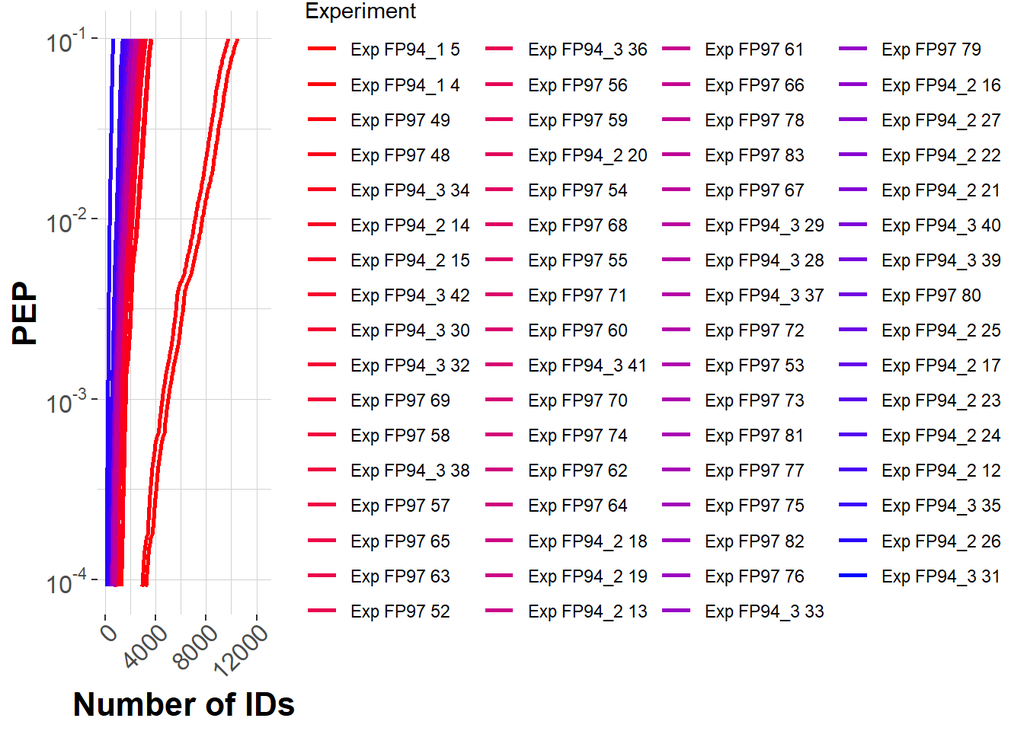

### Precursor Ion Fraction (PIF)

The distribution of PIFs for identified peptides across all sets, where PIF is a measure of coisolation (1 = pure, 0 = impure).

[figure not shown]

### Fractional ID Rate

Fractional rate of confident PSMs and PSMs from all MS2 scan events

[figure not shown]

### Total ID Rate

Number of MSMS scans, PSMs, and confident PSMs

[figure not shown]

## Contamination

### Number of ions by charge state

Plotting the frequency of charge states observed. This will give an if you are seeing mostly peptides or non-peptide species

[figure not shown]

### TIC of ions by charge state

Plotting the TIC of charge states observed. This will give an idea if you are seeing mostly peptides or non-peptide species

[figure not shown]

### MS1 Intensity, +1 ions

Plotting the intensity distribution of +1 ions, a diagnostic of non-peptide contaminants

[figure not shown]

### m/z Distribution for +1 ions

Plotting the m/z distribution of +1 ions, a diagnostic of non-peptide contaminants

[figure not shown]

### Intensity of z=1 across gradient

Plotting the intensity of z=1 ions observed. This will give an if you are seeing mostly peptides or non-peptide species and where they occur in the gradient

[figure not shown]

## SCoPE-MS Diagnostics

### Fraction of Missing Data per TMT Channel

This plot displays the fraction of missing values per reporter ion per run per TMT channel, reported as 0 by MaxQuant.

[figure not shown]

### Reporter Ion Intensities vs. Carrier Intensities

Comparing the reporter ion intensities for all TMT channels to the carrier channel, chosen automatically as the most intense channel (median intensity).

[output not shown]

### Reporter ion intensity

Plotting the TMT reporter intensities for a single run.

[output not shown]

### Relative reporter ion intensity

Plotting the TMT reporter intensities for a single run, normalized by the channel with the highest mean reporter ion intensity.

[output not shown]

### Reporter ion channel correlations

Plotting all pairwise TMT reporter ion intensity channel correlations (Pearson) for a single run.

[output not shown]

## DART-ID

### Error Probability Update

2D Densities of PSM error probabilities, given by MaxQuant (Spectra) and DART-ID. Points below the 45 degree line indicate boosted confidence (and lowered error probability), and vice versa for above the 45 degree line. Set the PEP slider to 1 to see all PSMs regardless of initial confidence.

[output not shown]

### Increase in Confident PSMs

Fold-change increase of PSMs at given confidence thresholds (in this case, FDR thresholds)

[output not shown]

### RT Alignment Error

Alignment Error (Predicted RT - Observed RT) for the RT Alignment in DART-ID

[output not shown]

### Peptide Identification Increase by Experiment

Increased number of peptide IDs per experiment, relative to existing IDs before DART-ID

[output not shown]

### Fractional ID Rate

Fractional rate of confident PSMs and PSMs from all MS2 scan events

[output not shown]

### Total ID Rate

Number of MSMS scans, PSMs, and confident PSMs

[output not shown]